# Projekt 1 - VaR

Estera Saidlo

29 marca 2019

## Wstęp

Do badania użyję metod:

- **historycznej prostej**,
- **historycznej z wagami**,
- **bootstrapowej**,
- **EWMA**.

**Metoda historyczna prosta** - sprowadza się do wykorzystania historycznych stóp zwrotu - w badaniu zostaną użyte geometryczne stopy zwrotu ze względu na relatywność (odniesienie do aktualnego kursu) oraz addytywność (zwrot w przedziale czasu [to-tk] jest sumą zwrotów w momentach t1,t2,…,tk). Następnie zostanie wyznaczony horyzont czasowy (500 dni), na podstawie którego nastąpi oszacowanie kwantyla rozkładu i wyznaczenie wartości VaR. Skuteczność symulacji historycznej jest uwarunkowana niezmiennością stóp zwrot w przyszłości w stosunku do danych historycznych.

**Metoda historyczna z wagami** - polega na nadaniu wyższej wagi obserwacjom “świeższym”. Jest tyle wag, ile obserwacji w jednym horyzoncie czasowym (500). Stopy zwrotu sortujemy rosnąco i na podstawie skumulowanych wag wyznaczamy odpowiedni kwantyl (99%). Jako wartość VaR bierzemy obserwację, która jako pierwsza przekroczyła współczynnik ufności.

**Metoda Bootstrapowa** - polega na 20-krotnym wylosowaniu ze zwracaniem próbki 1000 elementów spośród jednego okna historycznych stóp zwrotu(500 obserwacji), na tej podstawie zostają wyliczane wartości VaR(poprzez oszacowanie kwantyla rozkładu). Aby obliczyć wartość VaR przypadającą na konkretny dzień, zostanie wyliczona średnia z 20 wartości VaR.

**Metoda EWMA** - odrzuca ona założenie o stałości wariancji w czasie. Polega ona na wyliczeniu w każdym horyzoncie czasowym wariancji i nowych wartości, na podstawie których zostanie obliczony VaR i ES. W taki sam sposób jak w pozostałch metodach.

## Przedstawienie i wizualizacja danych

Badanie zostanie przeprowadzone na podstawie kursów walut:

- **EURO**,
- **THB (Bath tajski)**,
- **UAH (Hrywna ukraińska)**.

Poniżej zostaną przedstawione statystyki opisowe wybranych kursów walut:

```r
summary(kursy)
```

```
##       data                 THB              EUR             UAH
##  Min.   :2012-01-02   Min.   :0.0916   Min.   :3.982   Min.   :0.1094
##  1st Qu.:2013-09-30   1st Qu.:0.1032   1st Qu.:4.173   1st Qu.:0.1452
##  Median :2015-07-04   Median :0.1085   Median :4.221   Median :0.1709
##  Mean   :2015-07-01   Mean   :0.1071   Mean   :4.234   Mean   :0.2377
##  3rd Qu.:2017-03-29   3rd Qu.:0.1115   3rd Qu.:4.295   3rd Qu.:0.3800
##  Max.   :2018-12-31   Max.   :0.1192   Max.   :4.513   Max.   :0.4420
```

Poniżej zostaną przedstawione wykresy zmiany kursów poszczególnych walut w czasie:

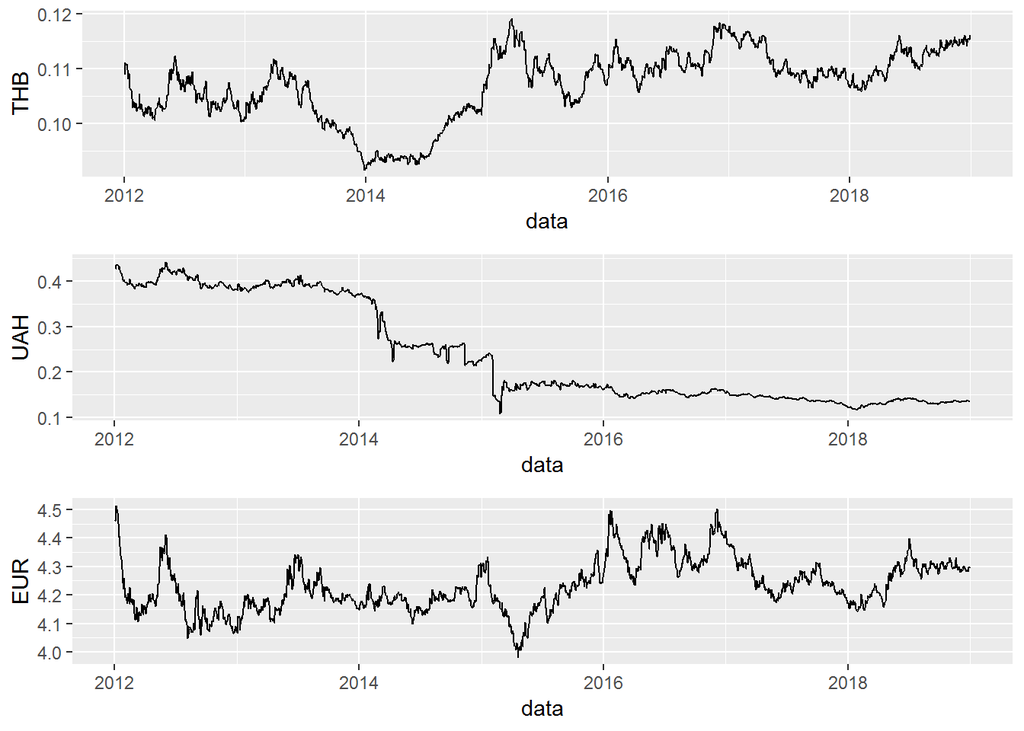

Przez większość czasu kurs THB utrzymywał się w przedziale od 0.10 do 0.12 zł. Waluta straciła na wartości pod koniec 2013 roku i do połowy 2014 jej wartość oscylowała w granicach 0.093, po czym zaczęła rosnąć. Najprawdopodobniej ten spadek był spowodowany kryzysem politycznym W Tajlandii, który trwał od października 2013 do maja 2014.

Kurs UAH niemal do końca 2013 roku oscylował w granicach 0.4 zł. W 2014 roku następował spadek, który trwał do pierwszych miesięcy 2015 roku, gdzie kurs ustabilizował się przy wartości ok. 0.15 zł.

EURO jest walutą dosyć stabilną. Do połowy 2015 roku jej wartość oscylowała w granicach 4.2 zł. w 2016 roku średnia wartość wzrosła do ok. 4.35, po czym spadła, a od połowy 2018 roku ustabilizowała się na wartości 4.3 zł.

## Przeprowadzenie badania

### Metoda historyczna prosta

```r
#datę biorę o 502, gdyż potrzebuję tylko tych które mają obliczony VaR
doVaR_h <- data.frame(date = kursy$data[-(1:501)])
hist <- function(dane){
  data <- data.frame(data = dane)
  st_zwrotu <- c()
  VAR <- c()
  ES <- c()
  for (i in 2:nrow(data)){
    st_zwrotu[i] <- log(data[i,]/data[i-1,])
  }
  st_zwrotu <- st_zwrotu[-1]
  data <- data[-1,1]
  for(j in 1:(length(data) - 499)){
    okno <- st_zwrotu[j:(499+j)]
    #przedstawienie straty jako wartość dodatnią
    VAR[499+j] <- -quantile(st_zwrotu[j:(j+499)],0.01, na.rm = T)
    ES[499+j] <- - mean(okno[st_zwrotu[j:(499+j)] <= -VAR[499+j]])
  }
  st_zwrotu <- st_zwrotu[-(1:500)]
  VAR <- VAR[-(1:500)]
  ES <- ES[-(1:500)]
  data <- data[-(1:500)]

  doVaR_h <- cbind(doVaR_h, data, st_zwrotu, VAR,ES)
  melt <- melt(doVaR_h, id.vars = c("date", "data"), na.rm = T)
  z <- ggplot(melt, aes(x = date, y = value, colour = variable)) + geom_line()
  plot(z)
  return(doVaR_h$VAR)
}
```

##### **EURO**

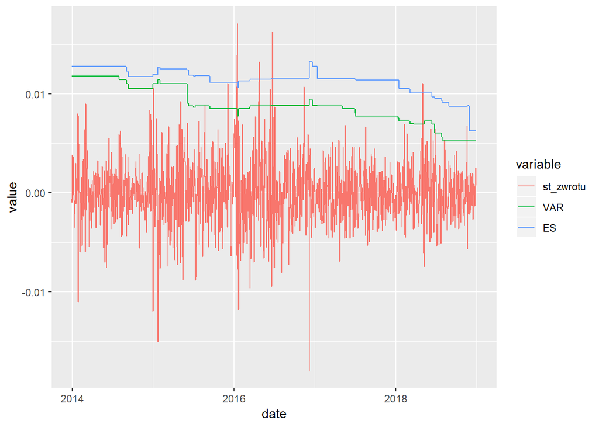

Według metody historycznej wartość narażona na ryzyko w przypadku EURO zmienia się z czasem i przyjmując 1% poziom istotności błędu nie przekroczy ona wartości wyznaczonej przez linię zieloną. Gdybyśmy chcieli zarabiać na zmianach kursu EURO w latach 2014-2018 to na 99% nie stracilibyśmy więcej niż ok. 0.013 zł na 1 EURO. Niebieska linia znajdująca się powyżej wartości narażonej na ryzyko informuje o tym, jaka będzie oczekiwana strata w tym 1% przypadków, kiedy stracimy więcej niż zakłada VaR. Szum wyznaczony przez linię czerwoną prezentuje rzeczywiste dzienne zmiany kursu EURO. Można dostrzec obserwacje, w których dzienne zmiany przekraczają wartość narażoną na ryzyko. Jednak ważne jest, aby procent obserwacji wychodzących poza poziom VaR oscylował w granicach przyjętego poziomu istotności - 1%. Jeśli będzie on istotnie mniejszy, będzie oznaczało to, że wartość VaR została przeszacowana, a gdy będzie on większy to znaczy, że ryzyko jest istotnie większe niż wskazuje szacunek. W te sposób godząc się na pewny poziom ryzyka można stracić znacznie wiecej.

##### **UAH**

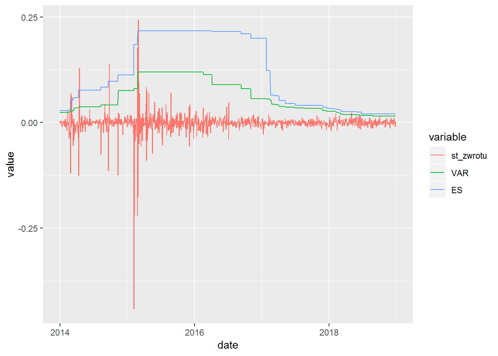

W przypadku UAH największe ryzyko występowało na początku 2015, gdzie dzienne zmiany były duże. Inwestując w tym czasie w kurs UAH na 99% możnaby stracić ok 0.12 zł na 1 UAH. Gdybyby poziom straty przekroczył wartość VaR, to możnaby stracić ok 0.2 zł na 1 UAH. Można zauważyć, że jak wartość VaR rośnie, to ES jest bardziej oddalone od VaR na wykresie. Jeżeli natomiast wartość VaR jest mniej więcej na tym samym poziomie to wartość ES jest do niej zbliżona.

##### **THB**

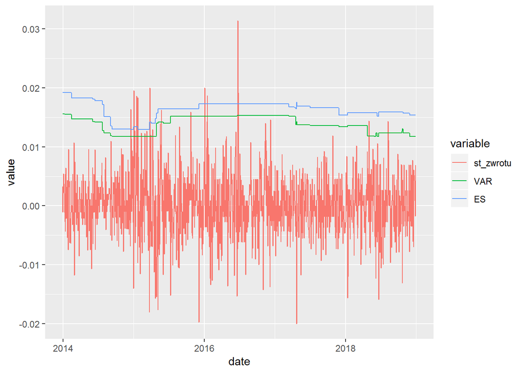

Jeśli chodzi o THB to wykres pokazuje, że wartość VaR może być trochę niedoszacowana pod koniec 2014 i na początku 2015 roku gdyż jest dużo obserwacji, które w tym okresie przekraczają VaR i ES. Widać, że wartość VaR nie zmienia się znacząco w czasie, przez cały badany okres znajduje się w przedziale (0.01 - 0.02).

### Metoda historyczna “z wagami”

```r
#datę biorę o 502, gdyż potrzebuję tylko tych które mają obliczony VaR
doVaR_w <- data.frame(date = kursy$data[-(1:501)])
hist_wag <- function(dane,q){
  data <- data.frame(data = dane)
  st_zwrotu <- c()
  VAR <- c()
  ES <- c()
  waga <- c()
  for(i in 1:500){
    waga[i] <- (q^(500-i) * (1-q)) / (1-q^500)
  }
  for (i in 2:nrow(data)){
    st_zwrotu[i] <- log(data[i,]/data[i-1,])
  }
  st_zwrotu <- st_zwrotu[-1]
  data <- data[-1,1]
  for(j in 1:(length(data) - 499)){
    zwag <- data.frame(st_zwrotu[j:(499+j)],waga)
    #sortowanie stóp zwrotu i liczenie skumulowanej sumy wag
    zwag <- zwag[order(zwag[,1]),]
    zwag <- cbind(zwag, skumulowane = cumsum(zwag$waga))
    #wzięcie pierwszej wartości przekraczającej poziom ufności
    VAR[499+j] <- -zwag[nrow(zwag[zwag$skumulowane <= 0.01,])+ 1,1]
    ES[499+j] <- - mean(zwag[ zwag$st_zwrotu<= -VAR[499+j],1])
  }
  st_zwrotu <- st_zwrotu[-(1:500)]
  VAR <- VAR[-(1:500)]
  ES <- ES[-(1:500)]
  data <- data[-(1:500)]

  doVaR_w <- cbind(doVaR_w, data, st_zwrotu, VAR,ES)
  melt <- melt(doVaR_w, id.vars = c("date", "data"), na.rm = T)
  z <- ggplot(melt, aes(x = date, y = value, colour = variable)) + geom_line()
  plot(z)
  return(doVaR_w$VAR)
}
```

##### **EURO**

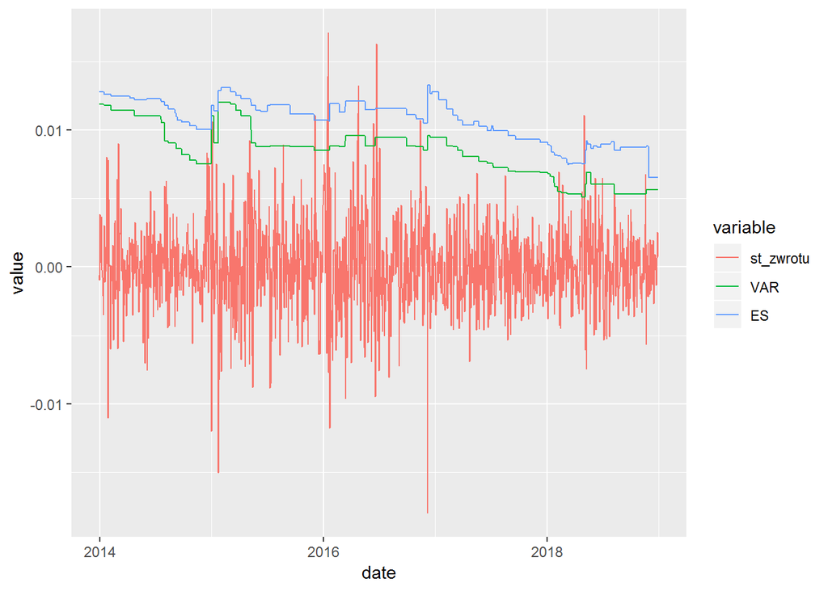

W metodzie z wagami można zaobserwować większą zmienność jeśli chodzi o wartości VaR i ES. Można zauważyć kilka obserwacji, które przekaczają VaR, choć na pierwszy rzuta oka wydają się one mieścić w dopuszczlnej liczbie wyjątków.

##### **UAH**

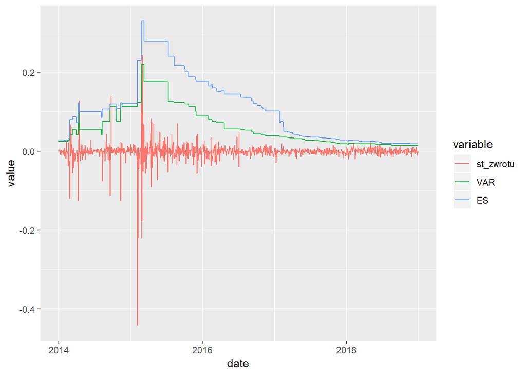

##### **THB**

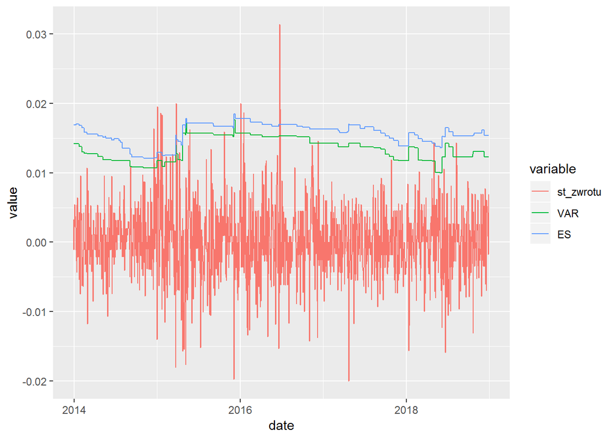

Dla THB w metodzi historycznej z wagami również spodziewam się niedoszacowania wartości VaR.

### Metoda bootstrapowa

```r
#datę biorę o 502, gdyż potrzebuję tylko tych które mają obliczony VaR
  doVaR_b <- data.frame(date = kursy$data[-(1:501)])
  boot <- function(dane){
    data <- data.frame(data = dane)
    st_zwrotu <- c()
    VAR <- c()
    ES <- c()
    for (i in 2:nrow(data)){
      st_zwrotu[i] <- log(data[i,]/data[i-1,])
    }
    st_zwrotu <- st_zwrotu[-1]
    data <- data[-1,1]
    for(j in 1:(length(data)-499)){
      vary <- NA
      es <- NA
      for(i in 1:20){
        #losuję 20 scenariuszy i liczę dla nich VaR i ES
        rand <- sample(st_zwrotu[j:(j+499)], 1000, replace = T)
        vary <- rbind(vary,-quantile(rand,0.01, na.rm = T))
        es <- rbind(es,-mean(rand[rand <= quantile(rand,0.01, na.rm = T)]))
      }
      #usuwam NA
      VAR[j+499] <- mean(vary[-1,])
      ES[499+j] <- mean(es[-1,])

    }
  st_zwrotu <- st_zwrotu[-(1:500)]
  VAR <- VAR[-(1:500)]
  ES <- ES[-(1:500)]
  data <- data[-(1:500)]

    doVaR_b <- cbind(doVaR_b, data, st_zwrotu, VAR,ES)
    melt <- melt(doVaR_b, id.vars = c("date", "data"), na.rm = T)
    z <- ggplot(melt, aes(x = date, y = value, colour = variable)) + geom_line()
    plot(z)
    return(doVaR_b$VAR)
  }
```

##### **EURO**

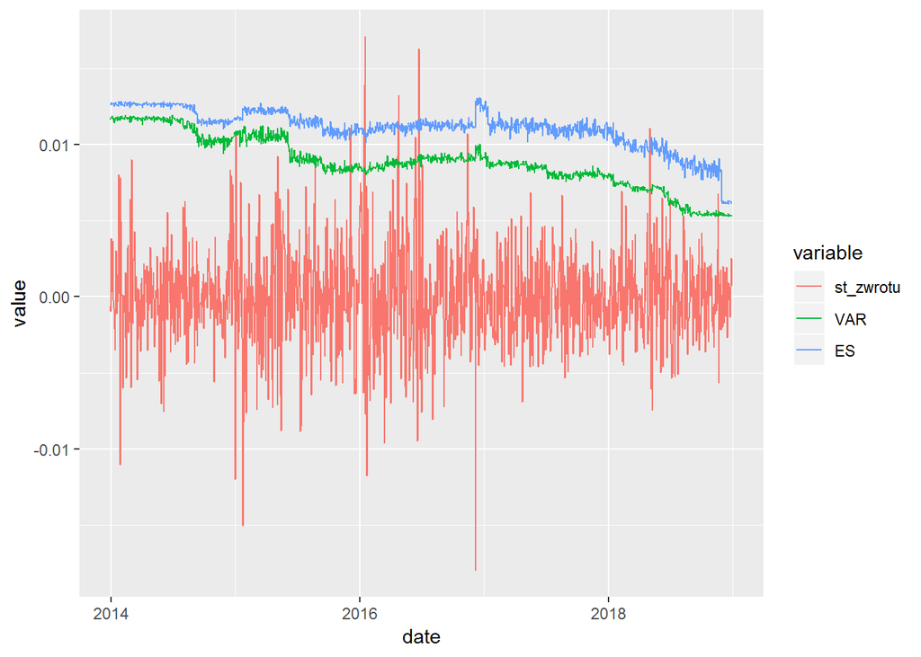

##### **UAH**

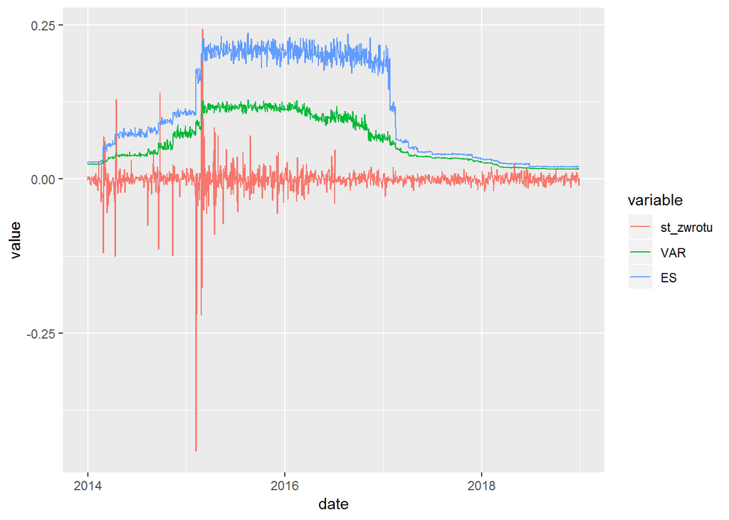

##### **THB**

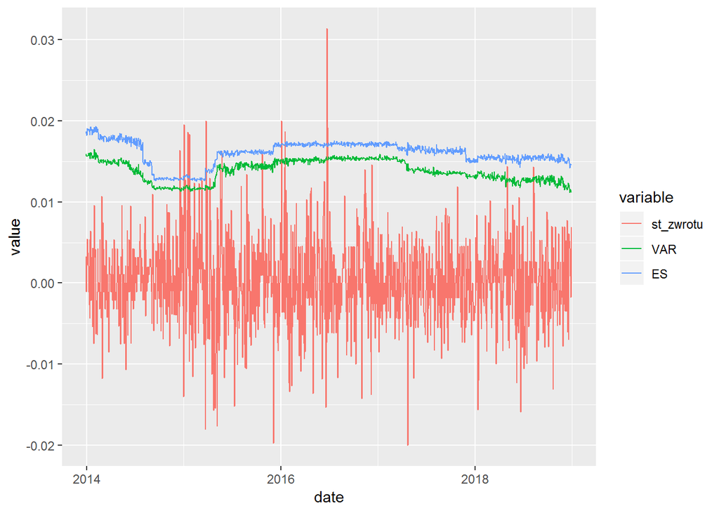

Metoda bootstrapowa, która bazuje na metodzie historycznej prostej, wydaje się dawać podobne wyniki dla każdej z trzech walut.

## Metoda EWMA

```r
#datę biorę o 502, gdyż potrzebuję tylko tych które mają obliczony VaR
doVaR_EWMA <- data.frame(date = kursy$data[-(1:501)])
EWMA <- function(dane, sigma1, lambda){
  data <- data.frame(data = dane)
  st_zwrotu <- c()
  VAR <- c()
  ES <- c()
  for (i in 2:nrow(data)){
    st_zwrotu[i] <- log(data[i,]/data[i-1,])
  }
  st_zwrotu <- st_zwrotu[-1]
  data <- data[-1,1]

  for(j in 1:(length(st_zwrotu) - 499)){
  okno <- st_zwrotu[j:(499+j)]
  sigma <- c(sigma1)
  wartosc <- c()
    #obliczanie wariancji dla okien
    for(i in 1:length(okno)){
    sigma[i+1] = sqrt(lambda *sigma[i] ^2 + (1-lambda) * okno[i]^2)
  }
  for(i in 1:length(okno)){
    wartosc[i] <- okno[i] * (sigma[length(sigma)]/sigma[i])
  }
    VAR[499+j] <- -quantile(wartosc,0.01, na.rm = T)
    ES[499+j] <- - mean(wartosc[wartosc <= -VAR[499+j]])
  }
  VAR <- VAR[-(1:500)]
  ES <- ES[-(1:500)]
  st_zwrotu <- st_zwrotu[-(1:500)]
  data <- data[-(1:500)]
  doVaR_EWMA <- cbind(doVaR_EWMA, data,st_zwrotu, VAR,ES)
  melt <- melt(doVaR_EWMA, id.vars = c("date", "data"), na.rm = T)
  z <- ggplot(melt, aes(x = date, y = value, colour = variable)) + geom_line()
  plot(z)
  return(doVaR_EWMA$VAR)
}
```

##### **EURO**

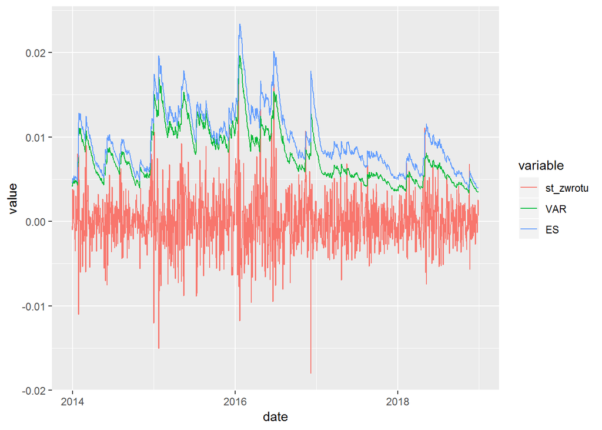

Metoda EWMA dla EURO choć nie odstaje aż tak bardzo od dziennych zmian, posiada bardzo mało wyjątków. Z tego względu spodziewam się dużego przeszacowania wartości VaR.

##### **UAH**

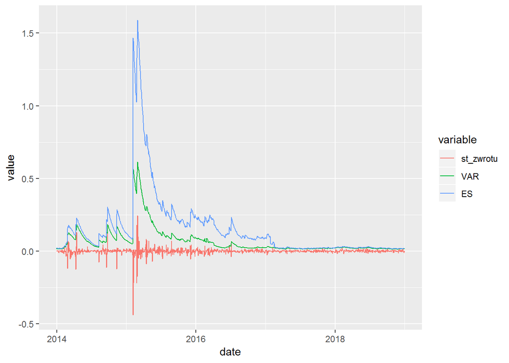

Dla UAH wyjątków nie ma prawie wcale, więc w tym przypadku metoda EWMA również się nie sprawdzi.

##### **THB**

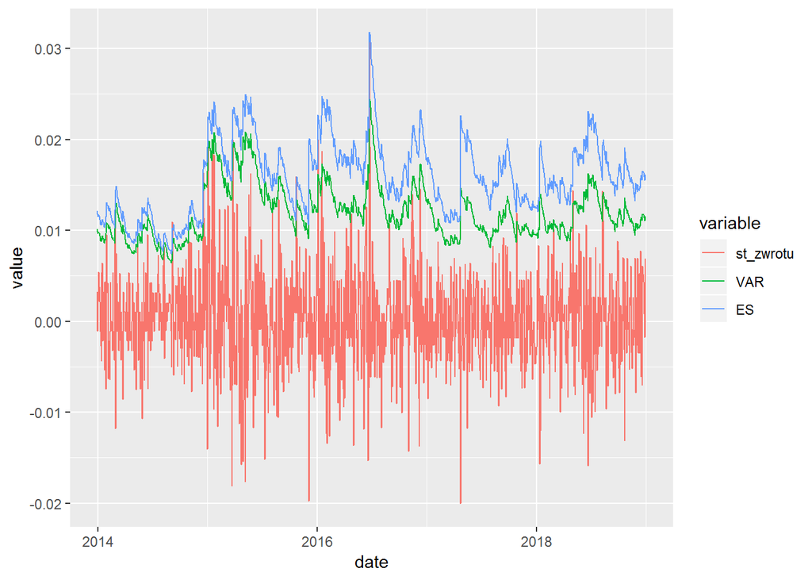

Dla THB sytuacja wygląda tak jak powyżej.

### Wykresy przedstawiające wartości VaR w zależności od metody

#### Wykresy VaR dla EURO

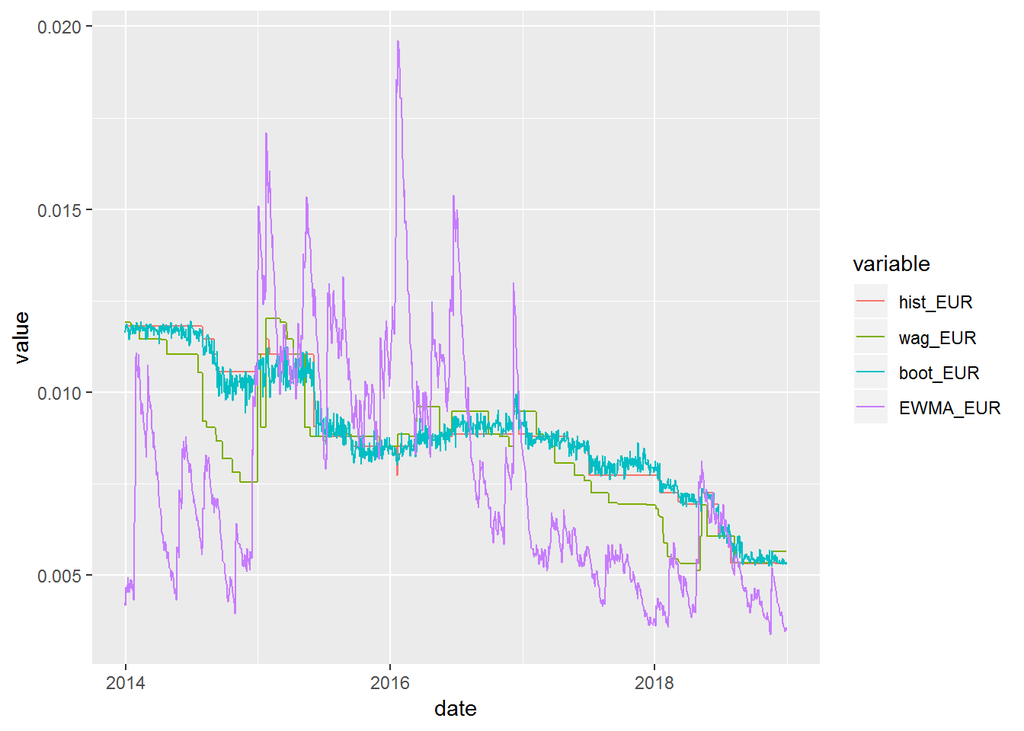

Metoda historyczna prosta i bootstrap dają niemalże identyczne wyniki. Metoda historyczna z wagami dla q = 0.995 mniej więcej pokrywa się z poprzednimi metodami, jednak można tu zauważyć już pewne odchylenia. Metoda EWMA natomiast odstaje najbardziej - w bardzo niewielkim stopniu pokrywa się z resztą metod.

#### Wykresy VaR dla UAH

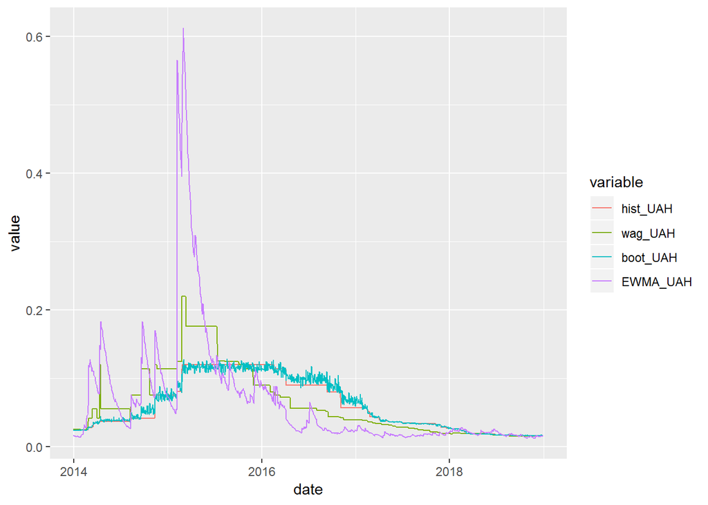

W 2015 roku dla UAH metoda EWMA zdecydowanie przeszacowała wartość VaR. Jej szacunkowa wartość w tamtym okresie wyniosła prawie 6 razy więcej niż wskazują metody historyczna prosta i bootstrapowa, zaś metoda historyczna z wagami wskazała wartość 2 razy większą.

#### Wykresy VaR dla THB

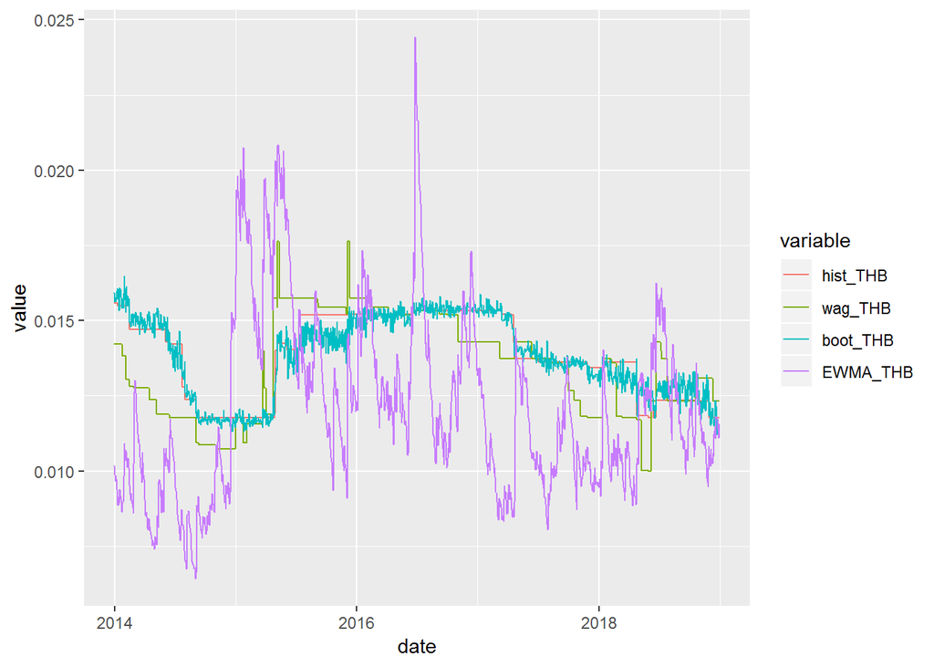

Dla THB różnice między metodami są podobne jak w przykładach powyżej. Metoda EWMA daje największe rozstrzały szacowanej wartości VaR.

```r
wsteczny <- function(stopy, var){
wyjatki <- 0
czyOk <- 0
#test wartości rzeczywistych
for (i in 1:length(st_zwrotu_EUR)){
  #strata jako wartość dodatnia
  if(-stopy[i] >= var[i])
  {
    wyjatki = wyjatki +1
  }
  proc <- sum(wyjatki)/length(st_zwrotu_EUR) * 100
}
#test zasięgu
  czyNiedoszacowany <- (1-pbinom(wyjatki-1, length(st_zwrotu_EUR), 0.01))*100
  czyPrzeszacowany <- (pbinom(wyjatki-1, length(st_zwrotu_EUR), 0.01))*100

  sprawdzenie <- data.frame(proc,czyNiedoszacowany,czyPrzeszacowany)
  return(sprawdzenie)
}
```

## Testy wsteczne

### Test wartości rzeczywistych i test zasięgu

W teście wartości rzeczywistych zostanie sprawdzony procent wyjątków - czyli przypadków, w których wartość VaR jest mniejsza niż strata. Procentowa wartość błędu powinna oscylować w granicach poziomu istotności, tj. 1%. Dodatkowo, aby sprawdzić czy procentowy wynik jest zadowalający, posłużę się testem zasięgu, który poinformuje, czy wartość VaR została przeszacowana, niedoszacowana, czy jest w porządku. Poniższe wyniki przedstawiają wartości procentowe. Jeśli w kolumnie “czyNiedoszacowany” lub “czyPrzeszacowany” pojawi się wartość mniejsza od 5% będziemy mieć informację, że wartość VaR została źle oszacowana. Idealna sytacja jest wtedy, gdy kolumny sprawdzające prawidłowe oszacowanie oscylują w granicach 50%.

#### Wyniki dla EURO

```r
EUR_h
```

```
##        proc czyNiedoszacowany czyPrzeszacowany
## 1 0.7125891          88.32994         11.67006
```

```r
EUR_w
```

```
##        proc czyNiedoszacowany czyPrzeszacowany
## 1 0.7917656          80.96797         19.03203
```

```r
EUR_b
```

```
##        proc czyNiedoszacowany czyPrzeszacowany
## 1 0.5542359          96.85248         3.147524
```

```r
EUR_EWMA
```

```
##        proc czyNiedoszacowany czyPrzeszacowany
## 1 0.3167063          99.86479        0.1352104
```

Wartości VaR dla Euro najlepiej szacuje metoda historyczna z wagami, której wartość błędu wynosi 0.79%. W pozostałych kolumnach nie pojawia się wartość mniejsza niż 5%, dlatego VaR jest obliczony dobrze, choć nie najlepiej, o czym świadczą wartości w pozostałych kolumnach. Metoda historyczna także mieści się w przedziale. Metoda EWMA i bootstrap natomiast prezentują się zdecydowanie najgorzej,gdyż zawyżyły wartość VaR.

### Wyniki dla UAH

```r
UAH_h
```

```
##       proc czyNiedoszacowany czyPrzeszacowany
## 1 1.187648          28.70179         71.29821
```

```r
UAH_w
```

```
##       proc czyNiedoszacowany czyPrzeszacowany
## 1 1.029295          49.60576         50.39424
```

```r
UAH_b
```

```
##       proc czyNiedoszacowany czyPrzeszacowany
## 1 1.266825          20.36442         79.63558
```

```r
UAH_EWMA
```

```
##         proc czyNiedoszacowany czyPrzeszacowany
## 1 0.07917656          99.99969     0.0003070795
```

Dla UAH zdecydowanie najlepiej sprawdziła się metoda z wagami. Jej oszacowanie jest niemalże idealne. Metoda bootstrapowa i historyczna prosta także są dobre, choć trochę odstają od wagowej. Meoda EWMA z kolei przeszacowała VaR.

### Wyniki dla THB

```r
THB_h
```

```
##        proc czyNiedoszacowany czyPrzeszacowany
## 1 0.7917656          80.96797         19.03203
```

```r
THB_w
```

```
##        proc czyNiedoszacowany czyPrzeszacowany
## 1 0.9501188          60.91329         39.08671
```

```r
THB_b
```

```
##        proc czyNiedoszacowany czyPrzeszacowany
## 1 0.9501188          60.91329         39.08671
```

```r
THB_EWMA
```

```
##        proc czyNiedoszacowany czyPrzeszacowany
## 1 0.3958828          99.52747        0.4725343
```

Dla THB metoda historyczna z wagami i bootstrapowa dają taki sam wynik, historyczna prosta jest gorsza, jednak mieści się w przedziale. Metoda EWMA po raz kolejny okazała się być najgorszą .

## Podsumowanie

Najlepszą metodą do szacowania wartości VaR dla każdej z walut okazała się być metoda historyczna z wagami, która w przypadku UAH sprawdziła się niemalże idealnie, a dla THB także ma całkiem fajny wynik. Najgorsze wyniki osiągnęła dla EURO. Metodę historyczną można postawić na drugim miejscu, gdyż w każdym przypadku mieści się w granicach dopuszczalnych, jednak jej poziom przeszacowania i niedoszacowania odbiega od 50%. Metoda bootstrap przeszacowała wartość VaR dla EURO. W pozostałych przypadkach jest w porzadku, chociaż dla THB prezentuje się lepiej. Zdecydowanie najgorszą z metod jest EWMA, która w każdym przypadku była tą metodą, która najsłabiej szacowała VaR.